# Formal Writeup

Paul Harmon

7/25/2021

# Introduction

Consider the problem of visualizing multivariate data (or potentially multivariate in many or high-dimensions). In many cases, it is useful to generate a 2 or 3-D mapping of some higher-dimensional space, projecting the high-dimensional data into an ordination that can be directly visualized. There are many methods that exist to accomplish this task, ranging from tools such as classicial multidimensional scaling (MDS) to more modern tools like t-distributed Stochastic Neighbor Embedding.

Unlike regression or classification, most tools for dimension reduction and higher-dimensional data visualization are unsupervised, meaning that they do not take advantage of some marked response variable; rather, they capitalize on the signal present in a set of features and produce a data-driven result. In regression models, we have a suite of tools to measure and assess unusual observations related to response vs. model predictions.

In a regression model, the estimated coefficients or predictions might be affected in meaningful fashion by the inclusion or exclusion of a single point - such points are referred to as influential (Cook, 1977). A suite of tools have been developed to identify and measure the impact of influential points on the results of regression models. Tools like t-SNE and MDS are also succeptible to abberant data values, much in the same way that a regression model might be succeptible to outliers and, specifically, influential points.

## Goal

The goal of this method is to develop a diagnostic that can be used to help identify influential points and potentially quantify how much they impact the resulting mapping, and create a tool that can be used with any mapping technique. Additionally, this method can be used to assess the sensitivity of each method to influential points and the impact that sensititivy might have on how an end user might want to interpret the resulting map produced. Note that while robustness to influential points might at first seem like a positive trait for an ordination method, masking distinctly different observations in a mapping may have negative consequences as well.

This document overviews the statistical methodology we have developed to identify influential points that, when excluded from a dataset, can meaningfully impact the shape of an ordination created from data. We overview our methodology step by step.

# Methods

This document assesses the effect of multivariate outliers on the maps produced by two methods: classical multidimensional scaling and t-SNE. In general, we seek to identify either **multivariate outliers** (or groups of them) which, for some reason, cause large differences in the shape of the resulting ordination. The methods rely on a few different ideas. First, PERMANOVA (Anderson, 2001) is a non-parametric, multivariate version of Analysis of Variance (ANOVA) that relies on a pseduo-F test to compare within-group and between group similarities based on a specified distance (dissimilarity) measure. Unlike ANOVA, PERMANOVA makes use of permutation tests to draw inferences without assuming distributions of test statistics.

Second, distance matrices contain information on point-to-point distances (or dissimilarities) and, when vectorized, the correlation of the distance matrices measures similarity of two configurations (Mantel’s test (Mantel, 1967) makes use of this approach to assess correlation between distance matrices).

Third, correlations (or similarities) can be converted to distances; one such metric for doing this is $\sqrt{2(1-r_{ij})}$ (James et al, 2013).

Finally, correlations can be computed using pairwise complete observations to leverage all available information to estimate correlations in the presence of some missing data values.

Our Permanova-based approach is as follows:

1. For each observation in the dataset, remove it, and generate a map in 2 dimensions from the resulting (n-1) observations for a selected ordination method. (For accounting purposes, it may make sense to keep the nx1 structure but replace the holdout observation with NA).
2. Generate a distance matrix of the nx1 by 2 matrix. Do this for each of the held-out observations.
3. Generate a pairwise-complete correlation matrix from the combination of these vectorized distances that measures similarity of distances (where available).
4. Convert that correlation matrix (of all the hold-out vectorized distance matrices) into a distance matrix using a
   $$\sqrt{2(1-r_{ij})}$$
   (James et al, 2013).
5. Apply non-parametric PERMANOVA tests for each holdout observation - this means that on a 100-observation dataset, you apply 100 individual tests where each test uses an independent variable that is equal to 1 for the index of the holdout observation and 0 elsewhere. The hypotheses are specified as such:
- $H_0$: No differences in map with observation j removed vs. those without j removed
- $H_a$: Some difference in map with observation j removed

We will discuss correcting p-values for multiple testing later, although currently our plan is to assess using Benjamini-Hochberg False Discovery Rate or Bonferroni corrections (or something similar, assuming that the results are based on p-values as in the Bonferroni Outlier test (Cook & Weisberg, 1982)). We would expect that if the maps are suitably distorted, or *influenced* by a single point, the resulting p-value for the jth adonis test would be small.

# Assessment on Data

## Token Example

The code below simulates the data with some clearly abberant values.

```r
set.seed(34536)
g1 <- rmnorm(n = 10, mean = rep(20, 10), diag(25, 10)) %>%
  t() %>%
  data.frame()
g2 <- rmnorm(n = 10, mean = rep(50, 20), diag(25, 20)) %>%
  t() %>%
  data.frame()
g3 <- rmnorm(n = 10, mean = rep(80, 30), diag(25, 30)) %>%
  t() %>%
  data.frame()


yes_structure <- rbind(g1, g2, g3) %>%
  data.frame() %>%
  mutate(Group = c(rep("1", 10), rep("2", 20), rep("3", 30)))

yes_structure_scale <- lapply(yes_structure[,1:10], scale) %>% as_tibble()

## adds outliers in the last 1 index (simulating from normal based on 5 sd's from mean)
add_outliers <- rbind(rnorm(10, 5, .5)) %>% as_tibble()
names(add_outliers) <- names(yes_structure_scale)


yes_structure_final <- bind_rows(yes_structure_scale, add_outliers)
yes_structure_final$Group <- c(yes_structure$Group, rep("Outlier",1))
```

1. For each observation in the dataset, remove it, and generate a (t-SNE or MDS) map in 2 dimensions from the resulting (n-1) observations. (For accounting purposes, it may make sense to keep the nx1 structure but replace the holdout observation with NA). The code below shows this as it pertains to the “multipermanova” function that I have written - it makes use of a function called “insert” from R.utils that adds NAs for each index that is held out.

```r
#initializes some stuff
perplexity = 10
data = yes_structure_final
n <- nrow(data)
  maplist <- list()
  cmdlist <- list()

#generate maps on holdout data
  for(j in 1:n){

    temp <- Generate_Holdout_Maps(data, j)
    cmdlist[[j]] <- temp$mds
    maplist[[j]] <- temp$tsne

  }

# Insert NAs into the holdout indices
  maplist_new <- list()
  cmdlist_new <- list()


#replaces holdouts with NAs
for(j in 1:length(maplist)){
    #create temporary vectors with NAs for each of the XY coordingates
    tempX <- R.utils::insert(maplist[[j]][,1], j, NA)
    tempY <- R.utils::insert(maplist[[j]][,2], j, NA)

    tempcmdX <- R.utils::insert(cmdlist[[j]][,1], j, NA)
    tempcmdY <- R.utils::insert(cmdlist[[j]][,2], j, NA)

    maplist_new[[j]] <- tibble(X = tempX, Y = tempY)
    cmdlist_new[[j]] <- tibble(X = tempcmdX, Y = tempcmdY)
}


#prints out the maps
maplist_new[[1]] %>% head()
```

```
## # A tibble: 6 x 2
##       X     Y
##   <dbl> <dbl>
## 1  NA    NA
## 2 -24.1 -29.5
## 3 -23.3 -29.3
## 4 -23.7 -30.2
## 5 -24.7 -30.5
## 6 -22.6 -30.3
```

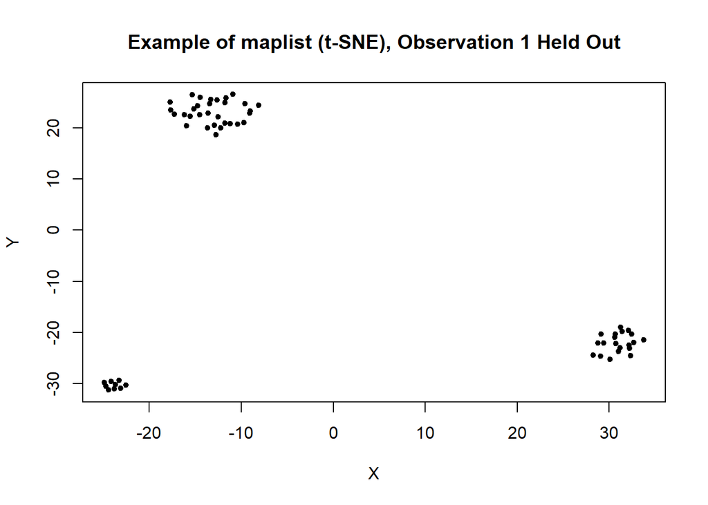

```r
plot(maplist_new[[1]], pch = 20, main = "Example of maplist (t-SNE), Observation 1 Held Out")
```

2. Generate a distance matrix of the n by 2 matrix. Do this for each of the held-out observations.
3. Vectorize the distance matrix and generate a correlation matrix(Pearson correlation based on pairwise-complete observations) from the combination of these vectorized distances.

We vectorize distance matrices in the following way, where $d12$ refers to the distance between the first and second observations (in the map). I’m ignoring the upper/lower triangle symmetry in this example. As an example, here’s what this looks like in a very simplistic 3 observation case, when the first observation is held out.

$$\mathbf{Dist(X_{nxn})} = \left[\begin{array}
{rrr}
NA & NA & NA \\
NA & 0 & d_{23} \\
NA & d_{32} & 0
\end{array}\right]$$

The vectorized form would be:
$$vec(\mathbf{c(Dist(X)))^T} = \left[\begin{array}
{r}
NA & NA & NA &
NA & 0 & d_{32} &
NA & d_{23} & 0
\end{array}\right]$$
Then, the matrix used to compare distance matrices is as follows, where each column comes from the ith holdout map. Note that the below notation reads: $d_{23, -1}$ is the distance between observations 2 and 3 on the map that holds out the 1st observation.

$$\mathbf{Cor(Dist(X))} = \left[\begin{array}
{rrr}
NA & d_{12, -2} & d_{13,-3} \\
NA & NA & d_{23,-3} \\
NA & d_{31,-2} & NA \\
NA & NA & ...\\
0 & NA & .\\
d_{32,-1} & NA & .\\
NA & d_{13,-2} & .\\
d_{23,-1} & NA & .\\
0 & 0 & .\\
\end{array}\right]$$

Because of the holdout NAs, we do not have complete cases to compare so instead we use pairwise-complete observations. We can see a visual representation of the NAs for a sample of the distance matrices below:

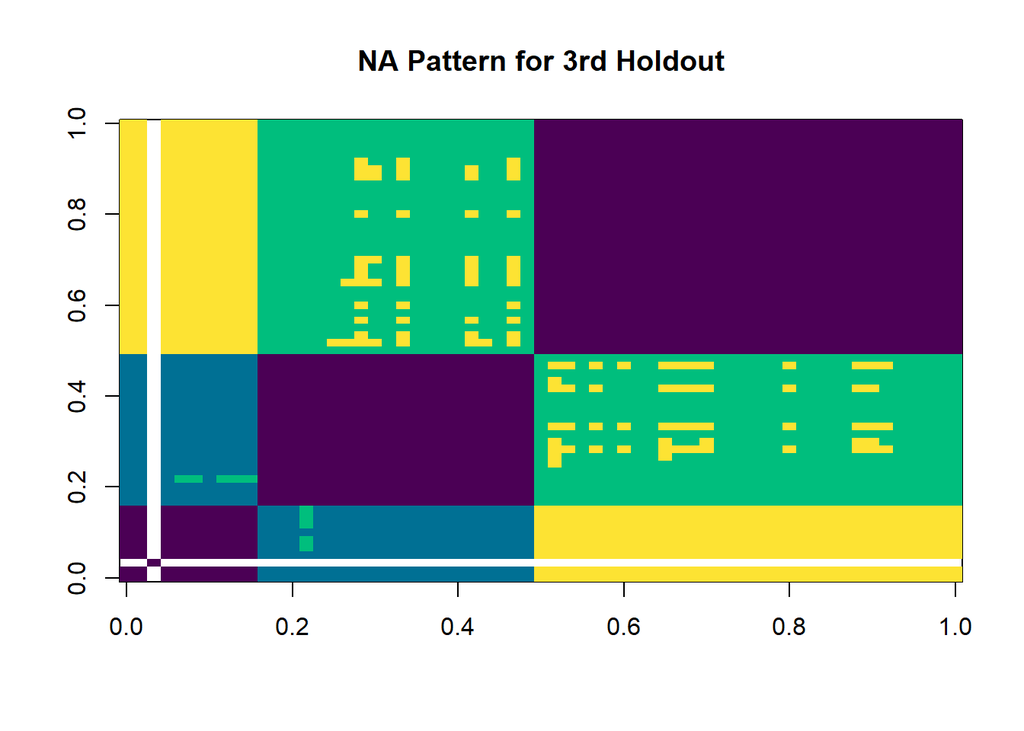

```r
#vectorizes the distances and outputs a list of vectorized distance matrices
  distmat_list <- lapply(maplist_new, dist)
  distmat_list_cmd <- lapply(cmdlist_new, dist)


#levelplot(as.matrix(distmat_list[[1]]), main = paste0("NA Pattern for ",1, "st Holdout"))
#levelplot(as.matrix(distmat_list[[3]]), main = paste0("NA Pattern for ",3, "rd Holdout"))
#levelplot(as.matrix(distmat_list[[5]]), main = paste0("NA Pattern for ",5, "th Holdout"))


image(as.matrix(distmat_list[[3]]), main = "NA Pattern for 3rd Holdout", col = hcl.colors(4))
```

The code chunk below shows both steps simultaneously.

```r
 #vectorizes the distances and outputs a list of vectorized distance matrices
  dist_list <- lapply(maplist_new, vectorize_dist)
  dist_list_cmd <- lapply(cmdlist_new, vectorize_dist)



  ## takes the vectorized distance matrices and binds the columns into a single data frame - to build correlation matrix

  dist_mat <- dist_list %>% as_tibble(.name_repair = "minimal")
  dist_mat_cmd <- dist_list_cmd %>% as_tibble(.name_repair = "minimal")

  #prints out the data frame of vectorized distance matrices to show what we're looking at
  head(dist_mat)
```

```
## # A tibble: 6 x 61
##      ``     ``     ``     ``     ``     ``     ``    ``    ``    ``    ``    ``
##   <dbl>  <dbl>  <dbl>  <dbl>  <dbl>  <dbl>  <dbl> <dbl> <dbl> <dbl> <dbl> <dbl>
## 1    NA NA      0.686  1.15   1.51   0.746  1.38  0.585 0.865 0.920 0.696 0.799
## 2    NA  0.534 NA      0.892  0.789  0.859  0.922 1.40  1.05  0.825 0.459 0.854
## 3    NA  1.26   0.835 NA      0.609  1.26   0.856 2.13  1.70  1.45  0.688 1.53
## 4    NA  0.984  1.07   0.708 NA      1.04   0.596 1.64  1.59  1.29  1.27  0.823
## 5    NA  0.801  1.51   1.86   1.23  NA      1.81  1.12  2.09  2.01  1.09  2.07
## 6    NA  1.91   0.993  1.78   2.06   1.88  NA     1.33  0.587 1.99  1.71  0.939
## # ... with 49 more variables: `` <dbl>, `` <dbl>, `` <dbl>, `` <dbl>, `` <dbl>,
## #   `` <dbl>, `` <dbl>, `` <dbl>, `` <dbl>, `` <dbl>, `` <dbl>, `` <dbl>,
## #   `` <dbl>, `` <dbl>, `` <dbl>, `` <dbl>, `` <dbl>, `` <dbl>, `` <dbl>,
## #   `` <dbl>, `` <dbl>, `` <dbl>, `` <dbl>, `` <dbl>, `` <dbl>, `` <dbl>,
## #   `` <dbl>, `` <dbl>, `` <dbl>, `` <dbl>, `` <dbl>, `` <dbl>, `` <dbl>,
## #   `` <dbl>, `` <dbl>, `` <dbl>, `` <dbl>, `` <dbl>, `` <dbl>, `` <dbl>,
## #   `` <dbl>, `` <dbl>, `` <dbl>, `` <dbl>, `` <dbl>, `` <dbl>, `` <dbl>,
## #   `` <dbl>, `` <dbl>
```

```r
  #dimensions are n*(n-1)/2 since the distance matrix is triangular - see below
  dim(dist_mat)
```

```
## [1] 1830   61
```

We calculate the correlation matrix from the above:

```r
  #Generates the correlation matrix based on pairwise complete observations, and pearson correlation

  #tsne
  cormat <- cor(dist_mat, use = "pairwise.complete.obs", method = "pearson")
  cormat %>% dim()
```

```
## [1] 61 61
```

```r
  #cmd
  cormat_cmd <- cor(dist_mat_cmd, use = "pairwise.complete.obs", method = "pearson")
  cormat_cmd %>% dim()
```

```
## [1] 61 61
```

4. Convert that correlation matrix (of all the hold-out vectorized distance matrices) into a distance matrix using the result that $D_{-i,-j} = \sqrt{2(1-r_{-i,-j})}$. Note that here, we expect that all the correlation values are greater than 0 - and as shown, they are.

*Note also that with this new distance matrix, we can actually create 2D visualizations (maps) from the distance matrix, creating a “map-of-maps” to show which of the ordinations are different from the rest. (Similarly, you could cluster maps or perform any distance-based method on this matrix to explore differences in the holdout ordinations).*

```r
## sanity check - these are all greater than 0
cormat %>% min()
```

```
## [1] 0.6597291
```

```r
##generate distance on correlation matrix
  cordist <- sqrt(2*(1-cormat)) %>% as.dist()
  cordist_cmd <- sqrt(2*(1-cormat_cmd)) %>% as.dist()
```

5. Apply non-parametric PERMANOVA tests for each holdout observation, using an indicator that is 1 for the holdout observation and 0 for all others. Cycle the indicator for each index - so you will apply $n$ individual tests.

In the code below, the data do not change - the calls to ‘adonis’ change only in that the index of the “1” for the indicator variable chanegs at each iteration. Thus, the indicator for the first holdout observation is [1,0,0,…] and so on and so forth.